# Assignment 6: Analysis of Longitudinal Data

### Step 4: Summary Measures

#### Mean Weight Profiles

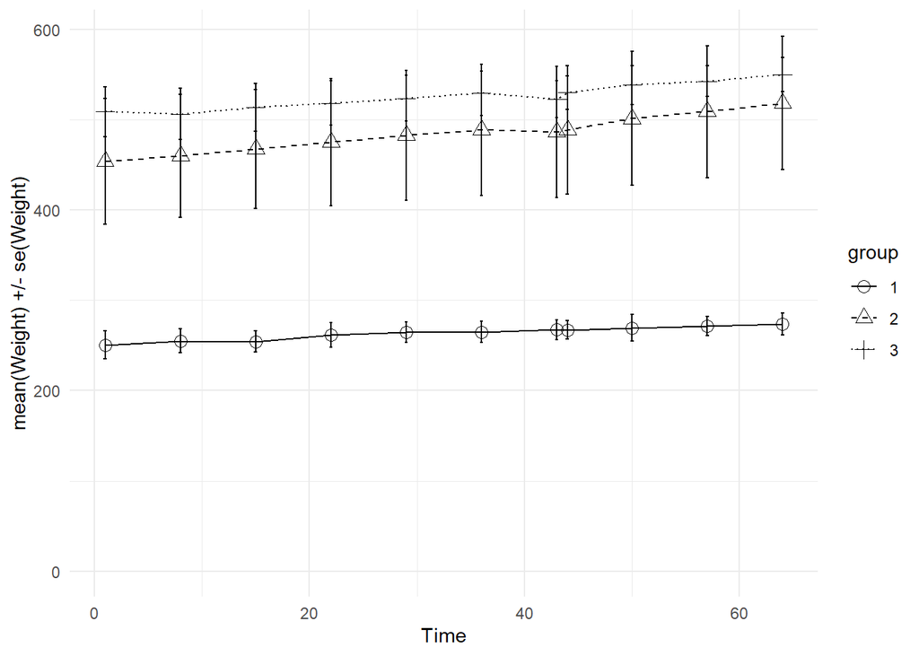

```r
# Number of rats (per group):
n <- 16

# Summary data with mean and standard error of weight by group and time
rats_summary <- rats %>%
  group_by(group, Time) %>%
  summarise( mean = mean(Weight), se = sd(Weight) ) %>%
  ungroup()

# Plot the mean profiles
ggplot(rats_summary,
       aes(x = Time,
           y = mean,
           linetype = group, shape = group)) +
  geom_line() +
  scale_linetype_manual(values = c(1,2,3)) +
  geom_point(size=3) +
  scale_shape_manual(values = c(1,2,3)) +
  geom_errorbar(aes(ymin=mean-se,
                    ymax=mean+se,
                    linetype="1"), width=0.3) +
  theme(legend.position = c(0.8,0.2)) +
  scale_y_continuous(name = "mean(Weight) +/- se(Weight)")+
  theme_minimal()
```

*Interpretations*

From the mean weight profile error bar plot we can see that there seems to be high errors present in group 2. This is particularly interesting as this is the group which exhibited the most change in weight according to our previous plots. When compared to group 1, group 3 has higher error rates. As group 1 exhibited the least weight change throughout the weeks so it makes sense that the error is lower. It also had more rats in the group (eight compared to the other groups with only 4) so this could have helped smooth out errors.

#### Boxplot

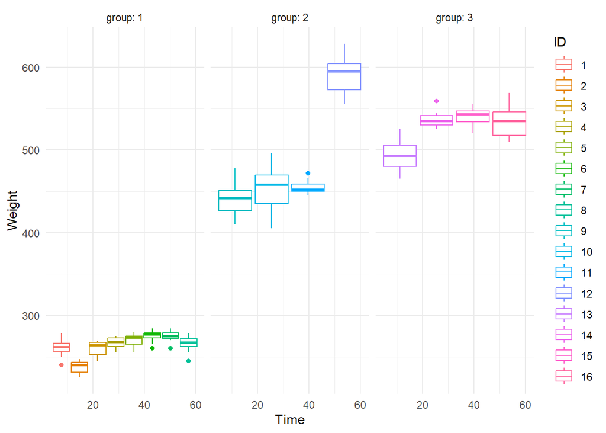

```r
rats %>%
  mutate(ID = as.factor(ID)) %>%
  ggplot(aes(x = Time, y = Weight, col = ID)) +
  geom_boxplot() +
  facet_wrap(~group, labeller = label_both) +
  theme_minimal()
```

*Interpretations*

#### Boxplots of Mean Summary Measures

```r
# create a summary data by group and ID with mean as the summary variable (ignoring baseline week 0)
rats_sum_mean <- rats %>%
  filter(Time > 0) %>%
  group_by(group, ID) %>%
  summarise(mean = mean(Weight)) %>%
  ungroup()

# glimpse the data
glimpse(rats_sum_mean)
```

```
## Rows: 16
## Columns: 3
## $ group <fct> 1, 1, 1, 1, 1, 1, 1, 1, 2, 2, 2, 2, 3, 3, 3, 3
## $ ID    <fct> 1, 2, 3, 4, 5, 6, 7, 8, 9, 10, 11, 12, 13, 14, 15, 16
## $ mean  <dbl> 261.0909, 237.6364, 260.1818, 266.5455, 269.4545, 274.7273, 274.…
```

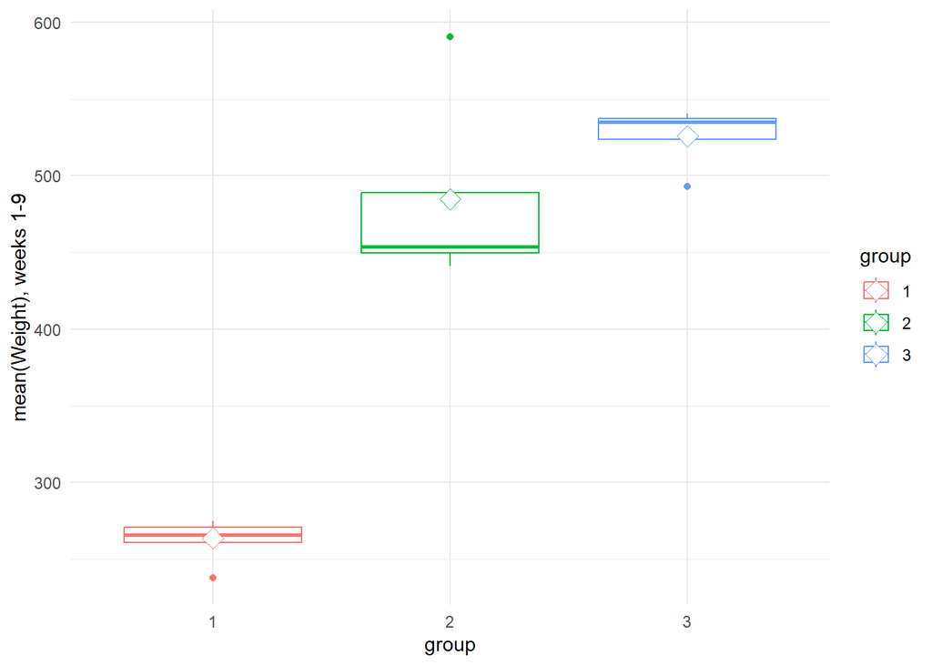

```r
# Draw a boxplot of the mean versus treatment
ggplot(rats_sum_mean,
       aes(x = group,
           y = mean,
           col = group)) +
  geom_boxplot() +
  stat_summary(fun = "mean", geom = "point", shape=23, size=4, fill = "white") +
  scale_y_continuous(name = "mean(Weight), weeks 1-9")+
  theme_minimal()
```

```r
# create new data by filtering outlier
rat_sum_mean <- rats_sum_mean %>% filter(group == 1 & mean > 238 |
                                         group == 2 & mean < 550 |
                                         group == 3 & mean > 500)

# glimpse the new data
glimpse(rat_sum_mean)
```

```
## Rows: 13
## Columns: 3
## $ group <fct> 1, 1, 1, 1, 1, 1, 1, 2, 2, 2, 3, 3, 3
## $ ID    <fct> 1, 3, 4, 5, 6, 7, 8, 9, 10, 11, 14, 15, 16
## $ mean  <dbl> 261.0909, 260.1818, 266.5455, 269.4545, 274.7273, 274.6364, 265.…
```

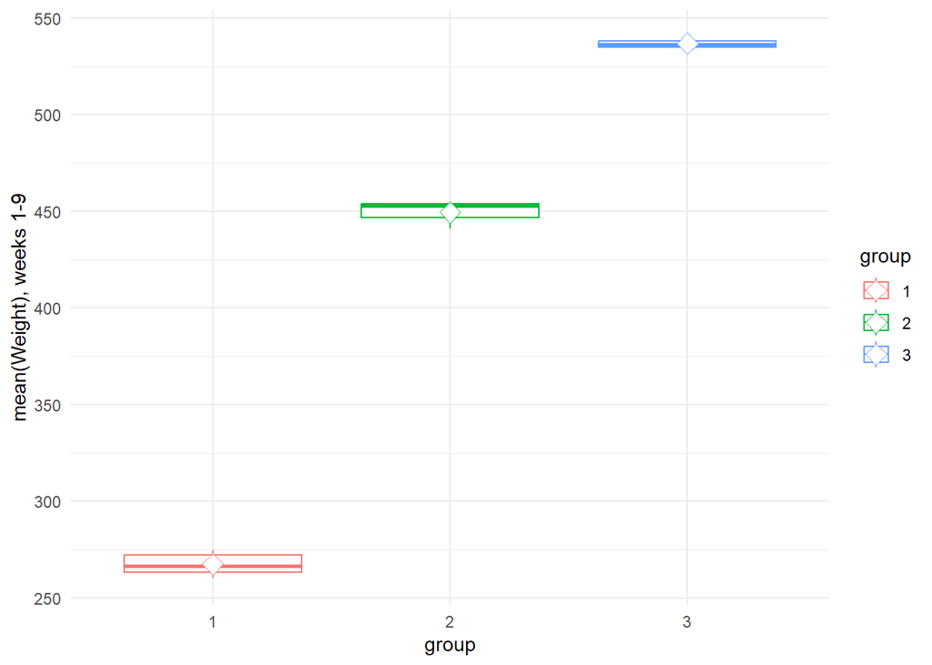

```r
# Draw a boxplot of the mean versus treatment
ggplot(rat_sum_mean,
       aes(x = group,
           y = mean,
           col = group)) +
  geom_boxplot() +
  stat_summary(fun = "mean", geom = "point", shape=23, size=4, fill = "white") +
  scale_y_continuous(name = "mean(Weight), weeks 1-9")+
  theme_minimal()
```

*Interpretations*

We Can clearly see how much influenced the outliers had on each group. This is especially true for group 2 which had a highly skewed distribution before removing the outlier. In the second plot - after removing the outliers - we can see that each group is less skewed. However, due to their differing scales it is hard to see more exactly how it influenced each of their distributions.

### ANOVA

```r
# read data in wide format

rats_anova <- read.table("https://raw.githubusercontent.com/KimmoVehkalahti/MABS/master/Examples/data/rats.txt", header = TRUE, sep = '\t')

# Add the baseline from the original data as a new variable to the summary data
rats_2 <- rats_sum_mean %>%
  mutate(baseline = rats_anova$WD1)

# Fit the linear model with the mean as the response
fit <- lm(mean ~ baseline + group, data = rats_2)

# Compute the analysis of variance table for the fitted model with anova()
anova(fit)
```

```
## Analysis of Variance Table
##
## Response: mean
##           Df Sum Sq Mean Sq   F value    Pr(>F)
## baseline   1 252125  252125 2237.0655 5.217e-15 ***
## group      2    726     363    3.2219   0.07586 .
## Residuals 12   1352     113
## ---
## Signif. codes:  0 '***' 0.001 '**' 0.01 '*' 0.05 '.' 0.1 ' ' 1
```

*Interpretations*

We can not reject the null hypothesis as firmly for the group variable. As the p-value for group is statistically significant at 90% CI (0.07586) we cannot say with total confidence that the average changes in weight for the rats were not equal between the three rat groups. In simpler terms, we can say only at a 90% level of certainty that the group - and thereby the diet - the rats were on influenced their average change in weight.

## BPRS Analysis

### Step 1: Set-up

#### Reading in the Data

```r
# read data from previously wrangled file (poor formatting because of wd issues)
bprs <- read.csv("~/Uni Helsinki/Year One/Teaching Period 2/Open Data Science/IODS-project_2022/data/bprs.csv", sep = ",")
```

#### Re-converting categorical variables to factor

```r
bprs$treatment <- factor(bprs$treatment)
bprs$subject   <- factor(bprs$subject)
```

### Step 2: Numerical Exploration

#### Numerical

##### Summaries

```r
summary(bprs)
```

```
##  treatment    subject       weeks                bprs            week
##  1:180     1      : 18   Length:360         Min.   :18.00   Min.   :0
##  2:180     2      : 18   Class :character   1st Qu.:27.00   1st Qu.:2
##            3      : 18   Mode  :character   Median :35.00   Median :4
##            4      : 18                      Mean   :37.66   Mean   :4
##            5      : 18                      3rd Qu.:43.00   3rd Qu.:6
##            6      : 18                      Max.   :95.00   Max.   :8
##            (Other):252
```

*Interpretations*

From the above summary we can see that the bprs test scores range from 18 to 95 with an average scores o 37.66. We can also see that we have two treatment groups with 180 observations and that there are eight weeks. Like the previous analysis, the graphical exploration of the data will follow in the coming section.

### Step 3: Linear Mixed Effect Model

#### Initial Visualization

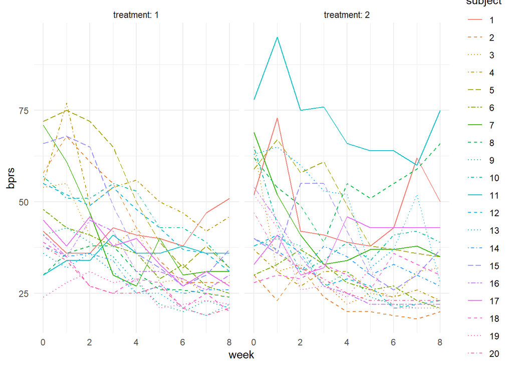

```r
ggplot(bprs, aes(x = week,
                 y = bprs,
                 linetype = subject,
                 col = subject)) +
  geom_line() +
  scale_linetype_manual(values = rep(1:10, times=4)) +
  facet_grid(. ~ treatment, labeller = label_both) +
  scale_y_continuous(name = "bprs") +
  theme_minimal()
```

*Interpretations*

From the plot we can see that there is a large variation among subjects and it is hard to see any clear trends. It appears as though there is little difference between the two treatments and that the change in bprs score seems to be dependent on the subject themselves.

#### Fitting Linear Mixed Models

##### Inital Regression Model Creation

```r
# create a regression model
bprs_reg <-  lm(bprs ~ week + treatment, data = bprs)

# print out a summary of the model
summary(bprs_reg)
```

```
##
## Call:
## lm(formula = bprs ~ week + treatment, data = bprs)
##
## Residuals:
##     Min      1Q  Median      3Q     Max
## -22.454  -8.965  -3.196   7.002  50.244
##
## Coefficients:
##             Estimate Std. Error t value Pr(>|t|)
## (Intercept)  46.4539     1.3670  33.982   <2e-16 ***
## week         -2.2704     0.2524  -8.995   <2e-16 ***
## treatment2    0.5722     1.3034   0.439    0.661
## ---
## Signif. codes:  0 '***' 0.001 '**' 0.01 '*' 0.05 '.' 0.1 ' ' 1
##
## Residual standard error: 12.37 on 357 degrees of freedom
## Multiple R-squared:  0.1851, Adjusted R-squared:  0.1806
## F-statistic: 40.55 on 2 and 357 DF,  p-value: < 2.2e-16
```

*Interpretations*

From the above model we can see that as the week is significant at the 99% CI (<2e-16). We can also see that there is a negative relationship between week and bprs score with a From coefficient of -2.27. This means that for each increase in week, there should be a 2.27 decrease in the subject’s bprs score. However, we can also see that treatment is not statistically significant. This means that there is not a statistically significant relationship between treatment type and the bprs score.

#### Random Intercept Model

```r
# create a random intercept model
bprs_ref <- lmer(bprs ~ week + treatment + (1 | subject), data = bprs, REML = FALSE)

# Print the summary of the model
summary(bprs_ref)
```

```
## Linear mixed model fit by maximum likelihood  ['lmerMod']
## Formula: bprs ~ week + treatment + (1 | subject)
##    Data: bprs
##
##      AIC      BIC   logLik deviance df.resid
##   2748.7   2768.1  -1369.4   2738.7      355
##
## Scaled residuals:
##     Min      1Q  Median      3Q     Max
## -3.0481 -0.6749 -0.1361  0.4813  3.4855
##
## Random effects:
##  Groups   Name        Variance Std.Dev.
##  subject  (Intercept)  47.41    6.885
##  Residual             104.21   10.208
## Number of obs: 360, groups:  subject, 20
##
## Fixed effects:
##             Estimate Std. Error t value
## (Intercept)  46.4539     1.9090  24.334
## week         -2.2704     0.2084 -10.896
## treatment2    0.5722     1.0761   0.532
##
## Correlation of Fixed Effects:
##            (Intr) week
## week       -0.437
## treatment2 -0.282  0.000
```

*Interpretation*

#### Random Intercept Model and Random Slope Model

```r
bprs_ref1 <- lmer(bprs ~ week + treatment + (week | subject), data = bprs, REML = FALSE)

# print a summary of the model
summary(bprs_ref1)
```

```
## Linear mixed model fit by maximum likelihood  ['lmerMod']
## Formula: bprs ~ week + treatment + (week | subject)
##    Data: bprs
##
##      AIC      BIC   logLik deviance df.resid
##   2745.4   2772.6  -1365.7   2731.4      353
##
## Scaled residuals:
##     Min      1Q  Median      3Q     Max
## -2.8919 -0.6194 -0.0691  0.5531  3.7976
##
## Random effects:
##  Groups   Name        Variance Std.Dev. Corr
##  subject  (Intercept) 64.8222  8.0512
##           week         0.9609  0.9802   -0.51
##  Residual             97.4305  9.8707
## Number of obs: 360, groups:  subject, 20
##
## Fixed effects:
##             Estimate Std. Error t value
## (Intercept)  46.4539     2.1052  22.066
## week         -2.2704     0.2977  -7.626
## treatment2    0.5722     1.0405   0.550
##
## Correlation of Fixed Effects:
##            (Intr) week
## week       -0.582
## treatment2 -0.247  0.000
```

```r
# perform an ANOVA test on the two models
anova(bprs_ref1, bprs_ref)
```

```
## Data: bprs
## Models:
## bprs_ref: bprs ~ week + treatment + (1 | subject)
## bprs_ref1: bprs ~ week + treatment + (week | subject)
##           npar    AIC    BIC  logLik deviance  Chisq Df Pr(>Chisq)
## bprs_ref     5 2748.7 2768.1 -1369.4   2738.7
## bprs_ref1    7 2745.4 2772.6 -1365.7   2731.4 7.2721  2    0.02636 *
## ---
## Signif. codes:  0 '***' 0.001 '**' 0.01 '*' 0.05 '.' 0.1 ' ' 1
```

*Interpretations*

From the random effects output we can see that 0.9609 is the amount of variability in the slope across weeks. We can also see that when a week’s intercept increases by one unit of standard deviation, there is a 0.51 standard deviations decrease in bprs scores. From the ANOVA output we can see that the random slope model is statistically significant at the 95% CI (0.026). This is an improvement on the previous model which was not statistically significant.

#### Random Intercept Model and Random Slope Model with Interaction

##### Create Model

```r
# create a random intercept and random slope model with the interaction
bprs_ref_interaction <- lmer(bprs ~ week * treatment + (week | subject),
                             data = bprs, REML = FALSE)

# print a summary of the model
summary(bprs_ref_interaction)
```

```
## Linear mixed model fit by maximum likelihood  ['lmerMod']
## Formula: bprs ~ week * treatment + (week | subject)
##    Data: bprs
##
##      AIC      BIC   logLik deviance df.resid
##   2744.3   2775.4  -1364.1   2728.3      352
##
## Scaled residuals:
##     Min      1Q  Median      3Q     Max
## -3.0512 -0.6271 -0.0768  0.5288  3.9260
##
## Random effects:
##  Groups   Name        Variance Std.Dev. Corr
##  subject  (Intercept) 64.9964  8.0620
##           week         0.9687  0.9842   -0.51
##  Residual             96.4707  9.8220
## Number of obs: 360, groups:  subject, 20
##
## Fixed effects:
##                 Estimate Std. Error t value
## (Intercept)      47.8856     2.2521  21.262
## week             -2.6283     0.3589  -7.323
## treatment2       -2.2911     1.9090  -1.200
## week:treatment2   0.7158     0.4010   1.785
##
## Correlation of Fixed Effects:
##             (Intr) week   trtmn2
## week        -0.650
## treatment2  -0.424  0.469
## wek:trtmnt2  0.356 -0.559 -0.840
```

```r
# perform an ANOVA test on the two models
anova(bprs_ref_interaction, bprs_ref1)
```

```
## Data: bprs
## Models:
## bprs_ref1: bprs ~ week + treatment + (week | subject)
## bprs_ref_interaction: bprs ~ week * treatment + (week | subject)
##                      npar    AIC    BIC  logLik deviance  Chisq Df Pr(>Chisq)
## bprs_ref1               7 2745.4 2772.6 -1365.7   2731.4
## bprs_ref_interaction    8 2744.3 2775.4 -1364.1   2728.3 3.1712  1    0.07495 .
## ---
## Signif. codes:  0 '***' 0.001 '**' 0.01 '*' 0.05 '.' 0.1 ' ' 1
```

*Interpretation*

It appears as though there were no significant changes from adding an interaction term to our model. From the ANOVA output we can see that the two models are very similar. The previous model, bprs_ref1 was significant at 95% whereas this model is significant at 90%. I thinks this means that we should use the previous model.

#### Plot observed and fitted values

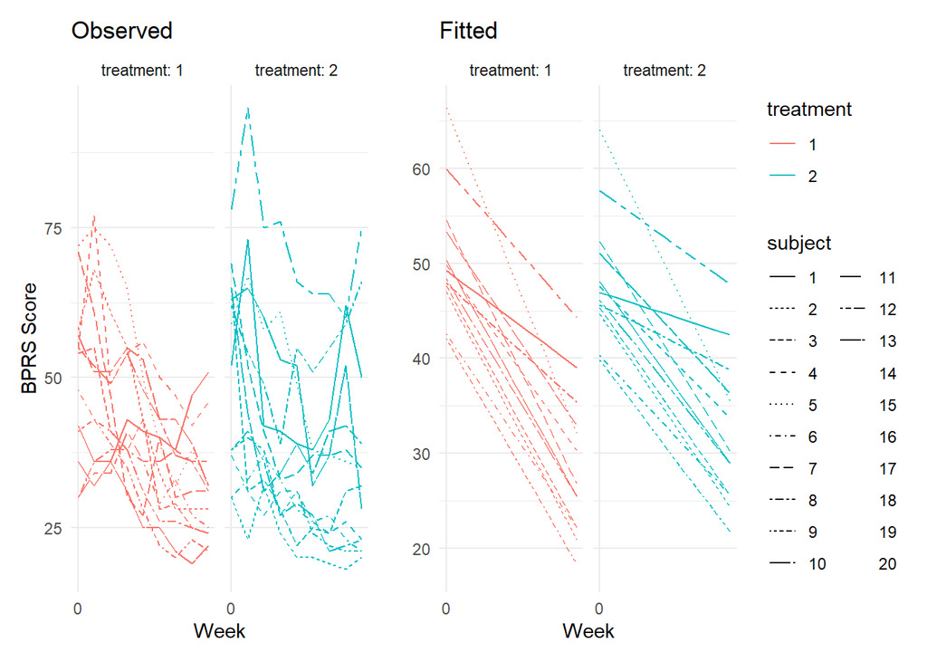

```r
# draw the plot of bprs with the observed bprs score values
p1 <- ggplot(bprs, aes(x = week,
                       y = bprs)) +
       geom_line(aes(linetype = subject,
                     col = treatment)) +
       facet_wrap(~treatment, labeller = label_both) +
       ggtitle("Observed") +
       guides(linetype="none", col = "none") +
       scale_x_continuous(name = "Week", breaks = seq(0, 60, 20)) +
       scale_y_continuous(name = "BPRS Score") +
       theme(legend.position = "none") +
       theme_minimal()

# Create a vector of the fitted values
Fitted <- fitted(bprs_ref_interaction)

# Create a new column fitted to bprs
bprs$fitted <- Fitted

# draw the plot of bprs with the Fitted values of bprs values
p2 <- ggplot(bprs, aes(x = week,
                       y = fitted)) +
  geom_line(aes(linetype = subject, col = treatment)) +
  facet_wrap(~treatment, labeller = label_both) +
  ggtitle("Fitted") +
  guides(linetype = guide_legend(nrow = 10)) +
  scale_x_continuous(name = "Week", breaks = seq(0, 60, 20)) +
  scale_y_continuous(name = "") +
  theme(legend.position = "bottom") +
  theme_minimal()

p1 + p2
```

*Interpretations*

I am not entirely sure how to interpret these two plots. My initial interpretation is that from the fitted values we can observe how there is little difference between the two treatments effect on bprs scores. We can also see that all subjects experienced a decrease in bprs scores over the course of eight weeks. It would be helpful to plot these lines with less subjects so it would be easier to match the subject from the observed plot to the corresponding line in the fitted plot.